# Predicting book success

Samal Abdikerimova, Ravi Donepudi, Carlos Salinas, and Xiran Yu

# Book review statistics

## Ideas

1. Look at relationship between reviews and pages.
2. Filter by language.
3. Relationship between popularity and gender.
4. Language and popularity.
5. Genre popularity through the years.
6. Publisher relationship with rating.
7. Publisher and gender relationship.

Note that there is an Goodreads API and that somebody has written an R interface to it, however we do not have enough time to explore it and get it to do as we want. What we will do instead is use the data set found on Kaggle [here](https://www.kaggle.com/jealousleopard/goodreadsbooks/)together with the Goodreads API to answer some of the questions above.

First we import the data and take a good look.

```r
books <- read_csv("data/books.csv") %>%
    rename(rating = average_rating,
           total_ratings = ratings_count,
           lang = language_code,
           pages = num_pages)
books
```

```
## # A tibble: 8,472 x 12
##    bookID title authors rating isbn  isbn13 lang  pages total_ratings
##     <dbl> <chr> <chr>    <dbl> <chr> <chr>  <chr> <dbl>         <dbl>
##  1      1 "Har… J.K. R…   4.57 0439… 97804… eng     652       2095690
##  2      2 "Har… J.K. R…   4.49 0439… 97804… eng     870       2153167
##  3      4 "Har… J.K. R…   4.42 0439… 97804… eng     352          6333
##  4      5 "Har… J.K. R…   4.56 0439… 97804… eng     435       2339585
##  5      8 "Har… J.K. R…   4.78 0439… 97804… eng    2690         41428
##  6      9 "Una… W. Fre…   3.74 0976… 97809… en-US   152            19
##  7     10 "Har… J.K. R…   4.73 0439… 97804… eng    3342         28242
##  8     12 "The… Dougla…   4.38 0517… 97805… eng     815          3628
##  9     13 "The… Dougla…   4.38 0345… 97803… eng     815        249558
## 10     14 "The… Dougla…   4.22 1400… 97814… eng     215          4930
## # … with 8,462 more rows, and 3 more variables: text_reviews_count <dbl>,
## #   publication_date <chr>, publisher <chr>
```

Let’s get more of an idea of what we are working with. Since we speak English we’d like to focus solely on English language books. But first let’s see how many of them we have

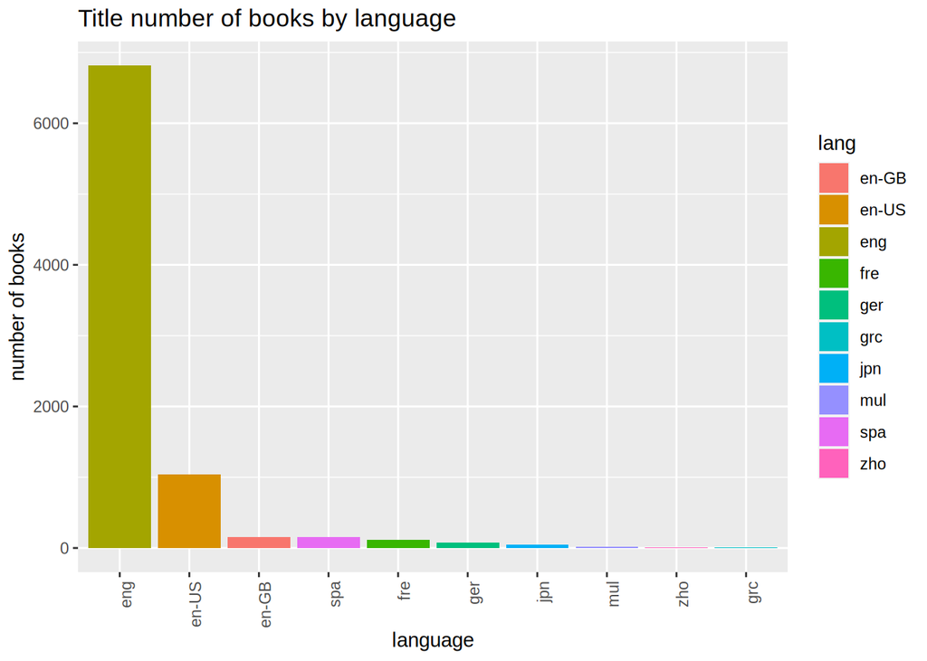

```r
books %>%
    subset(is.na(as.numeric(lang))) %>%
    subset(!is.na(lang)) %>%
    group_by(lang) %>%
    tally() %>%
    arrange(desc(n)) %>%
    slice(1:10) %>%
    ggplot(aes(x = factor(lang, levels = lang), y = n, fill = lang)) +
    geom_bar(stat = "identity") +
    labs(title = "Title number of books by language",
         x = "language",
         y = "number of books") +
    theme(axis.text.x = element_text(angle=90, hjust=1))
```

Nice, so the overwhelming majority of the data is in `eng`. However, it looks like US and Great Britain version of books fall under a different language tag (and if we search hard Canadian too). For our purposes `"en-CA",`“en-GB”`, and`en-US` are the same so let us clean up the data a little

```r
books$lang <- books %>%
    pull(lang) %>%
    str_replace_all("en*(g|-GB|-US|-CA)", "eng")
```

Another way to deal with this problem is simply to ignore these variants by filtering them out of the data set. Now, since the overwhelming majority of the books in this data set are in English, we will focus our attention on `"eng"`.

```r
eng_books <- books %>% filter(lang == "eng") %>% filter(rating >= 3)
```

One thing we might one to look at first is the distribution of ratings for English books. We do this as follows

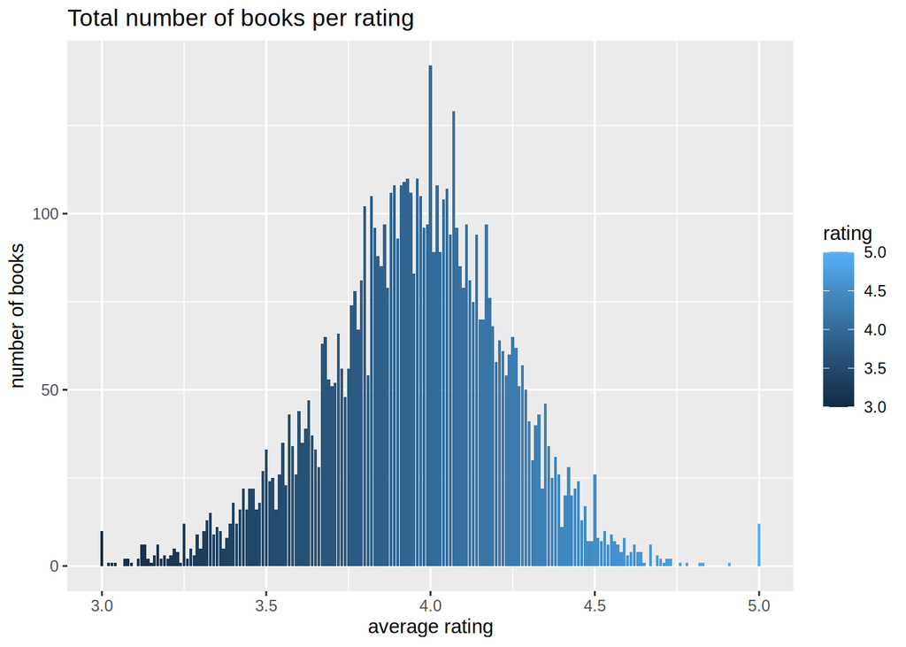

```r
eng_books %>%
    group_by(rating) %>%
    summarize(total_books = n()) %>%
    ungroup() %>%
    ggplot(aes(x = rating)) +
    geom_bar(aes(y = total_books/1.000001, fill = rating),
             stat = "identity") +
    labs(title = "Total number of books per rating",
         x = "average rating",
         y = "number of books")
```

and who are the most prolific writers

```r
prolific_writer_names <- eng_books %>%
    group_by(authors) %>%
    summarize(count = n()) %>%
    arrange(desc(count)) %>%
    ungroup() %>%
    slice(1:10) %>%
    pull(authors)

prolific_writers <- eng_books %>% filter(authors %in% prolific_writer_names)
```

```r
eng_books %>%
    group_by(authors) %>%
    summarize(average_rating = sum(rating)/n()) %>%
    arrange(desc(average_rating)) %>%
    ungroup() %>%
    slice(1:10)
```

```
## # A tibble: 10 x 2
##    authors                                              average_rating
##    <chr>                                                         <dbl>
##  1 Chris    Green/Chris Wright/Paul Douglas Gardner                  5
##  2 James E. Campbell                                                 5
##  3 Julie Sylvester/David Sylvester                                   5
##  4 Keith Donohue                                                     5
##  5 Laura Driscoll/Alisa Klayman-Grodsky/Eric     Weiner              5
##  6 Middlesex Borough Heritage Committee                              5
##  7 Ross Garnaut                                                      5
##  8 Sheri Rose Shepherd                                               5
##  9 Todd Davis/Marc Frey                                              5
## 10 William C. Dowling                                                5
```

who are these people? So highly rated authors are not necessarily notable ones, perhaps there is a better way to measure top authors.

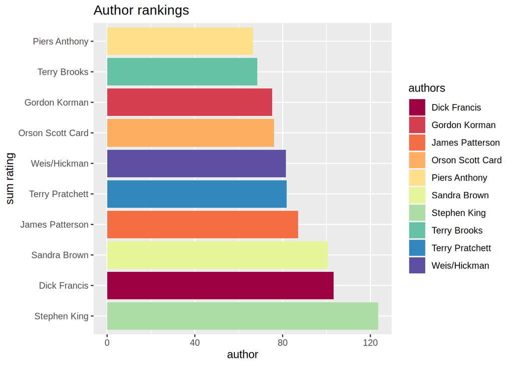

```r
eng_books %>%
    (function(...) {
        tmp <- tibble(...)
        tmp$authors <- tmp$authors %>%
            str_replace_all("Margaret Weis/Tracy Hickman",
                            "Weis/Hickman")
        tmp}) %>%
    group_by(authors) %>%
    summarize(book_count = n(),
              sum_rating = sum(rating)) %>%
    arrange(desc(sum_rating)) %>%
    slice(1:10) %>%
    ggplot(aes(factor(authors, levels = authors), sum_rating, fill = authors)) +
    geom_col() +
    coord_flip() +
    labs(title = "Author rankings",
         y = "author",
         x = "sum rating") +
    scale_fill_brewer(palette="Spectral")
```

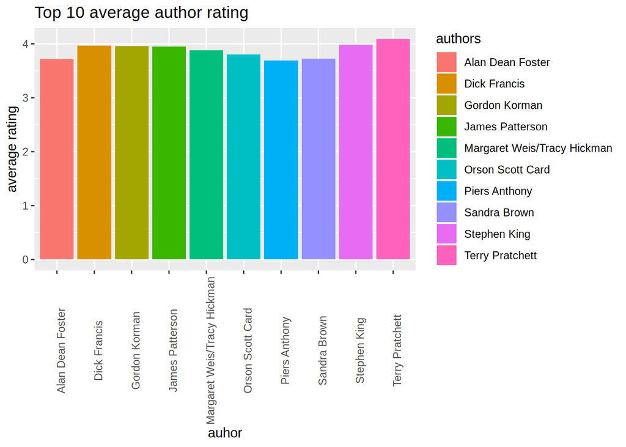

```r
prolific_writers %>%
    group_by(authors) %>%
    summarize(avg_rat = sum(rating)/n()) %>%
    ungroup() %>%
    ggplot(aes(x = authors, y = avg_rat, fill = authors)) +
    geom_bar(stat = "identity") +
    labs(title = "Top 10 average author rating",
          x = "auhor",
          y = "average rating") +
    theme(axis.text.x = element_text(angle = 90))
```

```r
eng_books <- eng_books %>%
    mutate(publication_year = as.numeric(str_sub(publication_date, -4)))
```

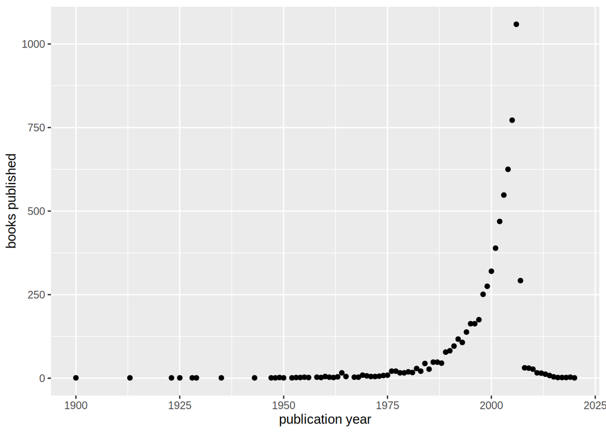

```r
eng_books %>% group_by(publication_year) %>%
    summarize(total_books = n()) %>%
    ungroup() %>%
    ggplot(aes(x = publication_year, y = total_books)) +
    geom_point() +
    xlim(1900, 2020) +
    labs(x = "publication year",
         y = "books published")
```

```r
books_per_year <- eng_books %>% group_by(publication_year) %>%
    summarize(total_books = n()) %>%
    arrange(desc(total_books)) %>%
    ungroup()
```

```r
model_publish_books <- books_per_year %>%
    filter(publication_year <= 2006) %>%
    lm(log(total_books) ~ publication_year, .)

filtered_model <- books_per_year %>%
    filter(publication_year > 2006) %>%
    lm(log(total_books) ~ publication_year, .)

model_publish_books %>% tidy()
```

```
## # A tibble: 2 x 5
##   term              estimate std.error statistic  p.value
##   <chr>                <dbl>     <dbl>     <dbl>    <dbl>
## 1 (Intercept)      -155.       8.82        -17.6 5.87e-26
## 2 publication_year    0.0799   0.00447      17.9 2.40e-26
```

```r
filtered_model %>% tidy()
```

```
## # A tibble: 2 x 5
##   term             estimate std.error statistic     p.value
##   <chr>               <dbl>     <dbl>     <dbl>       <dbl>
## 1 (Intercept)       696.      71.3         9.77 0.000000459
## 2 publication_year   -0.345    0.0354     -9.74 0.000000475
```

```r
estimate_2020 <-
    predict(model_publish_books,
            newdata = data.frame(publication_year = seq(2015,2020)))
```

```r
stephen_king <- books %>% filter(authors == "Stephen King" &
                                 title != "Blood and Smoke" &
                                 title != "LT's Theory of Pets")
sk_model <- lm(rating ~ pages, stephen_king)
sk_model %>% tidy()
```

```
## # A tibble: 2 x 5
##   term        estimate std.error statistic  p.value
##   <chr>          <dbl>     <dbl>     <dbl>    <dbl>
## 1 (Intercept) 3.62      0.111        32.7  1.03e-26
## 2 pages       0.000795  0.000217      3.67 8.61e- 4
```

```r
predict(sk_model,
        newdata = data.frame(pages = c(300)))
```

```
##        1
## 3.855764
```

```r
stephen_king %>% summarize(mean = mean(pages))
```

```
## # A tibble: 1 x 1
##    mean
##   <dbl>
## 1  478.
```

```r
eng_books$publisher <- factor(eng_books$publisher)
```

```r
top_10_publishers <- eng_books %>%
    group_by(publisher) %>%
    summarize(total_books = n()) %>%
    arrange(desc(total_books)) %>%
    slice(1:10) %>%
    pull(publisher)
```

```r
eng_books_tp <- eng_books %>%
    filter(publisher %in% top_10_publishers)
```